# econ_data_20210704_074122

```python
import importlib
import pathlib
import os
import sys
from datetime import datetime
module_path = os.path.abspath(os.path.join('../..'))
if module_path not in sys.path:
    sys.path.append(module_path)
```

```python
datetime.now()
```

```
datetime.datetime(2021, 7, 4, 7, 41, 24, 560708)
```

```python
report_name=f"econ_{datetime.now().strftime('%Y%m%d_%H%M%S')}"
base_path=os.path.abspath(os.path.join('../..'))
```

```python
# Parameters
report_name = "econ_data_20210704_074122"
base_path = "/Users/DidierRodriguesLopes/Documents/GamestonkTerminal"
```

```python
cache_dir = pathlib.Path(base_path, "notebooks", "reports", report_name)
if not os.path.isdir(cache_dir):
    print(f"Reports data directory not found. Creating {cache_dir}")
    os.mkdir(cache_dir)
else:
    print(f"Found reports directory {cache_dir}")
    print(os.listdir(cache_dir))
```

```
Reports data directory not found. Creating /Users/DidierRodriguesLopes/Documents/GamestonkTerminal/notebooks/reports/econ_data_20210704_074122
```

```python
from gamestonk_terminal.papermill import econ_data_helper as edh
```

## Dow Jones - 2 year trend with 20, 50 and 200 day SMA

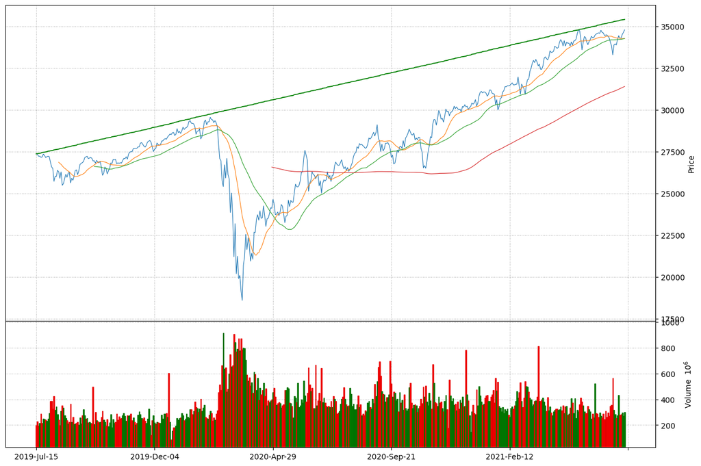

```python
edh.draw_graph("^DJI", cache_dir, line_type="line", draw_mas=(20,50,200), draw_volume=True, time_delta=720, low_trend=False)
```

## Dow Jones - 1 year trend with 20, 50 and 200 day SMA

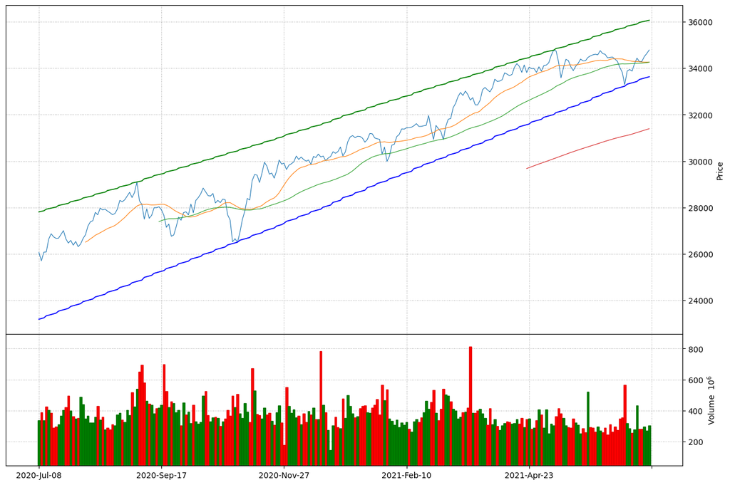

```python
edh.draw_graph("^DJI", cache_dir, line_type="line", draw_mas=(20,50,200), draw_volume=True, time_delta=360, low_trend=True)
```

## S&P 500 - 2 year trend with 20, 50 and 200 day SMA

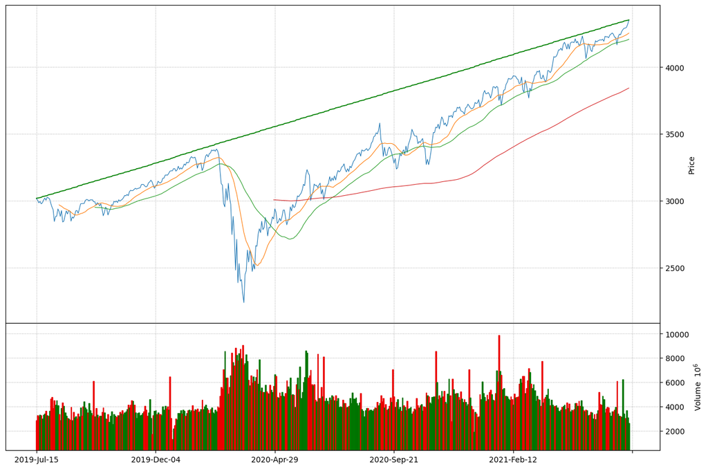

```python
edh.draw_graph("^GSPC", cache_dir, line_type="line", draw_mas=(20,50,200), draw_volume=True, time_delta=720, low_trend=False)
```

## Market Volatility (VIX) - 2 year trend with 20, 50 and 200 day SMA

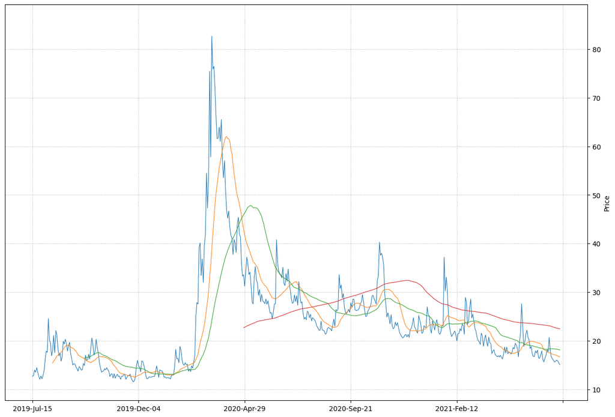

```python
edh.draw_graph("^VIX", cache_dir, line_type="line", draw_mas=(20,50,200), draw_volume=False, time_delta=720, high_trend=False, low_trend=False)
```

## Market Volatility (VIX) - 1 year trend with 20, 50 and 200 day SMA

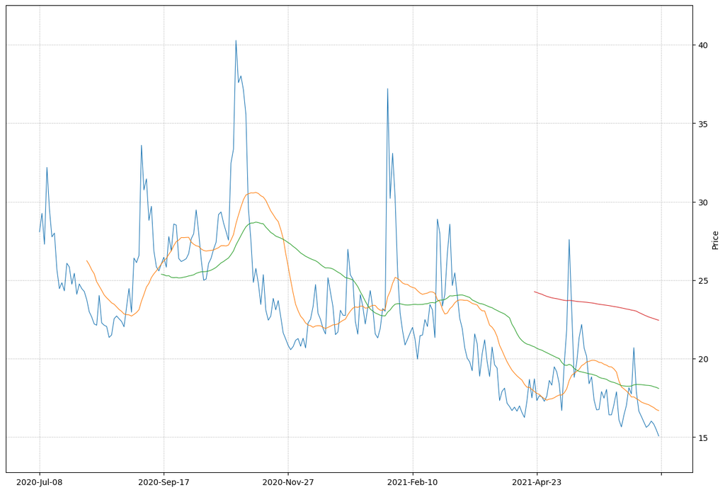

```python
edh.draw_graph("^VIX", cache_dir, line_type="line", draw_mas=(20,50,200), draw_volume=False, time_delta=360, high_trend=False, low_trend=False)
```

## Yield on 5-Year US Treasury Notes - 2 year trend with 20, 50 and 200 day SMA

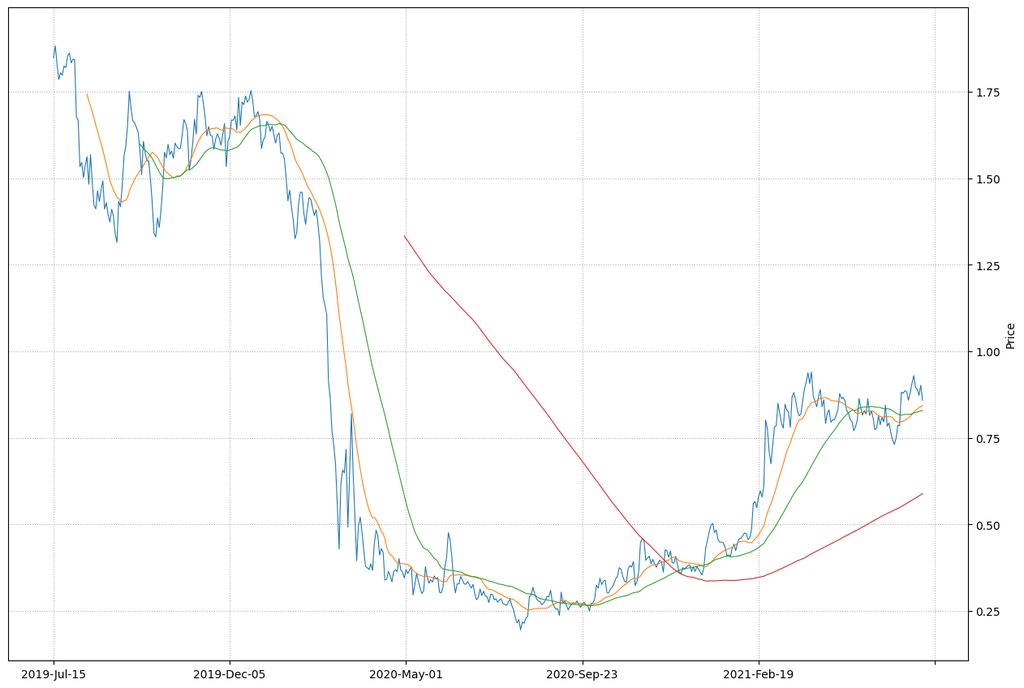

```python
edh.draw_graph("^FVX", cache_dir, line_type="line", draw_mas=(20,50,200), draw_volume=False, time_delta=720, low_trend=False, high_trend=False)
```

## Yield on 10-Year US Treasury Notes - 2 year trend with 20, 50 and 200 day SMA

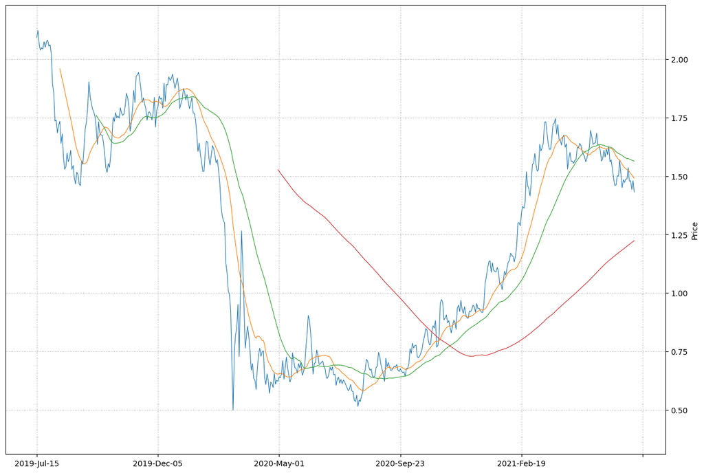

```python
edh.draw_graph("^TNX", cache_dir, line_type="line", draw_mas=(20,50,200), draw_volume=False, time_delta=720, low_trend=False, high_trend=False)
```

## Yield on 30-Year US Treasury Notes - 2 year trend with 20, 50 and 200 day SMA

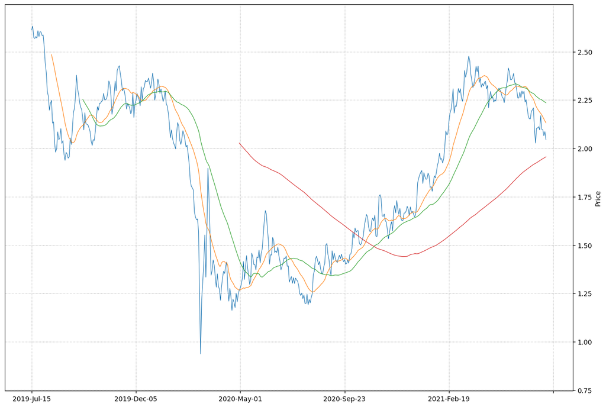

```python
edh.draw_graph("^TYX", cache_dir, line_type="line", draw_mas=(20,50,200), draw_volume=False, time_delta=720, low_trend=False, high_trend=False)
```

## Gold - 2 year trend with 20, 50 and 200 day SMA

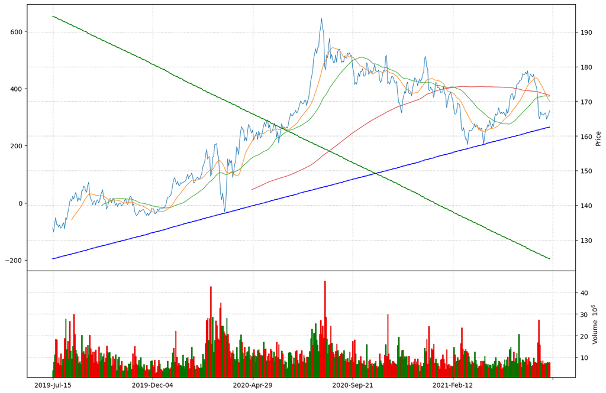

```python
edh.draw_graph("GLD", cache_dir, line_type="line", draw_mas=(20,50,200), draw_volume=True, time_delta=720)
```

## Silver - 2 year trend with 20, 50 and 200 day SMA

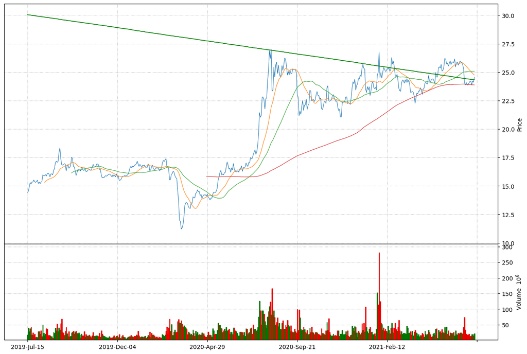

```python
edh.draw_graph("SLV", cache_dir, line_type="line", draw_mas=(20,50,200), draw_volume=True, time_delta=720, low_trend=False)
```

## Euro vs US Dollar - 2 year trend with 20, 50 and 200 day SMA

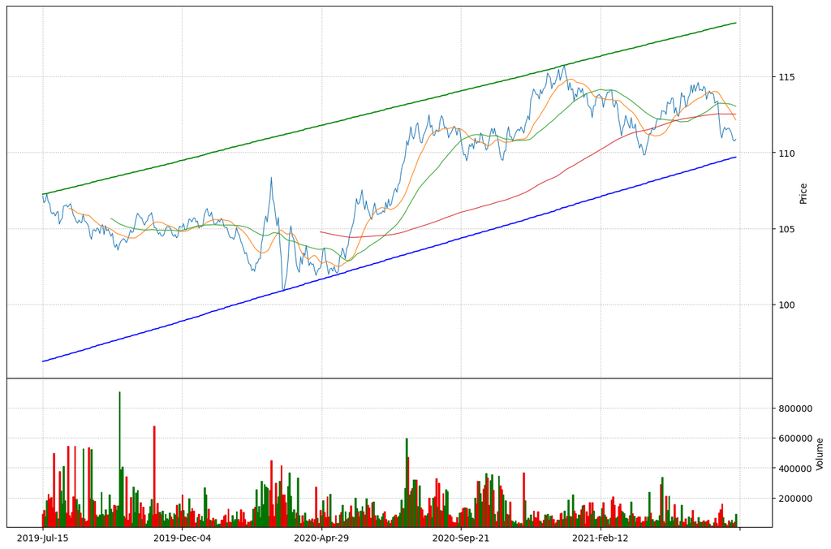

```python
edh.draw_graph("FXE", cache_dir, line_type="line", draw_mas=(20,50,200), draw_volume=True, time_delta=720, low_trend=True)
```

## Yen vs US Dollar - 2 year trend with 20, 50 and 200 day SMA

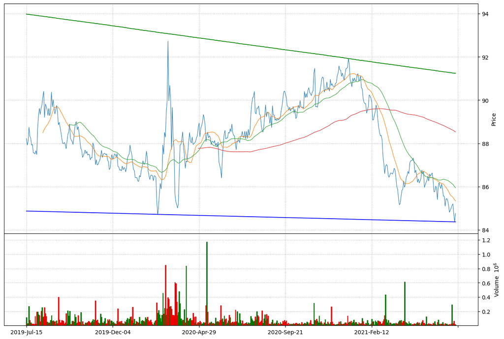

```python
edh.draw_graph("FXY", cache_dir, line_type="line", draw_mas=(20,50,200), draw_volume=True, time_delta=720, low_trend=True)
```

## Energy - 2 year trend with 20, 50 and 200 day SMA

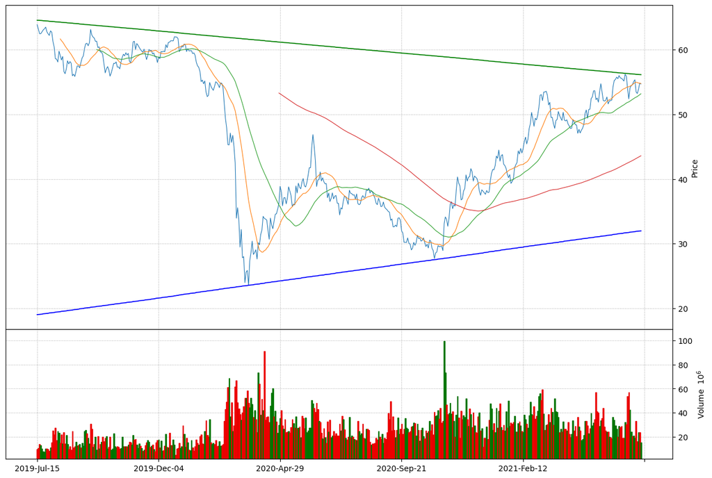

```python
edh.draw_graph("XLE", cache_dir, line_type="line", draw_mas=(20,50,200), draw_volume=True, time_delta=720)
```

## Crude Oil - 2 year trend with 20, 50 and 200 day SMA

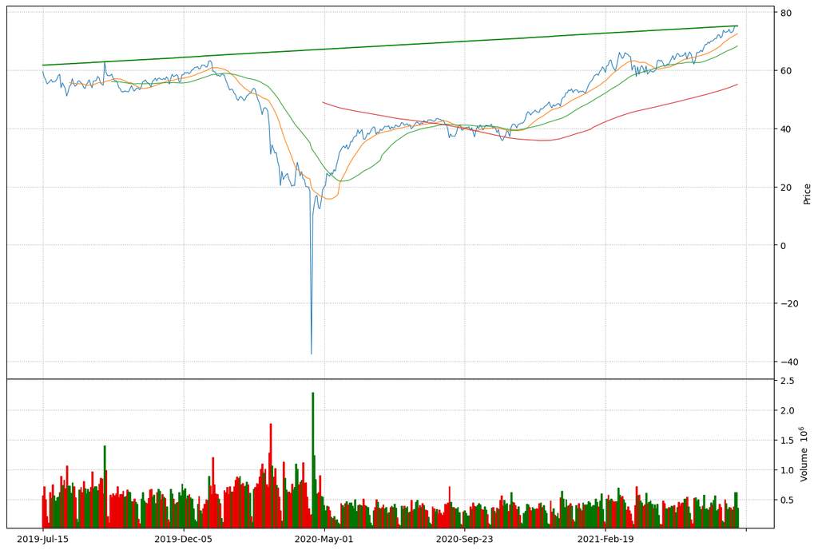

```python
edh.draw_graph("CL=F", cache_dir, line_type="line", draw_mas=(20,50,200), draw_volume=True, time_delta=720, low_trend=False)
```

## Real Estate - 2 year trend with 20, 50 and 200 day SMA

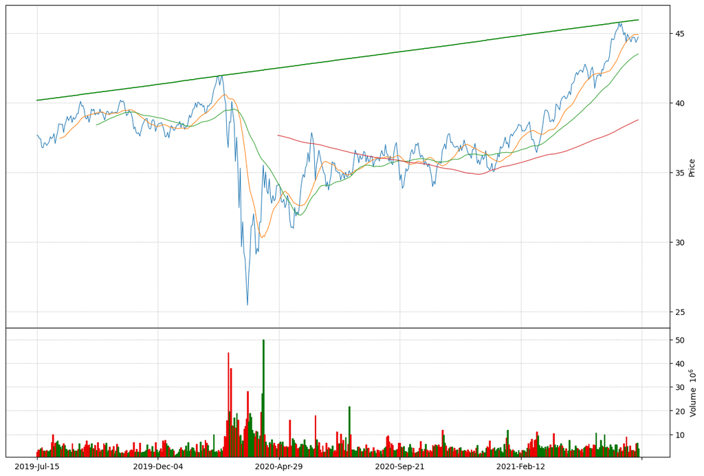

```python
edh.draw_graph("XLRE", cache_dir, line_type="line", draw_mas=(20,50,200), draw_volume=True, time_delta=720, low_trend=False)
```

## Real Estate - 1 year trend with 20, 50 and 200 day SMA

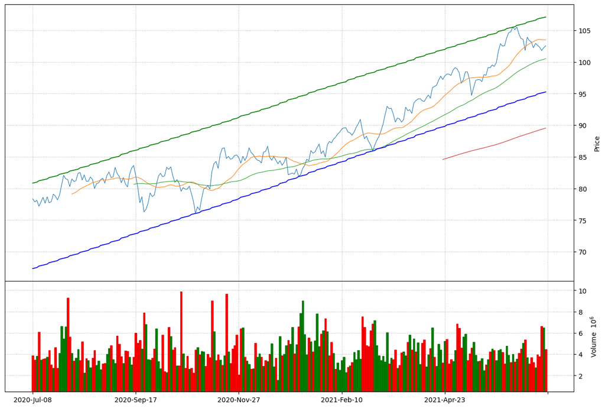

```python
edh.draw_graph("VNQ", cache_dir, line_type="line", draw_mas=(20,50,200), draw_volume=True, time_delta=360, low_trend=True)
```

## Financials - 2 year trend with 20, 50 and 200 day SMA

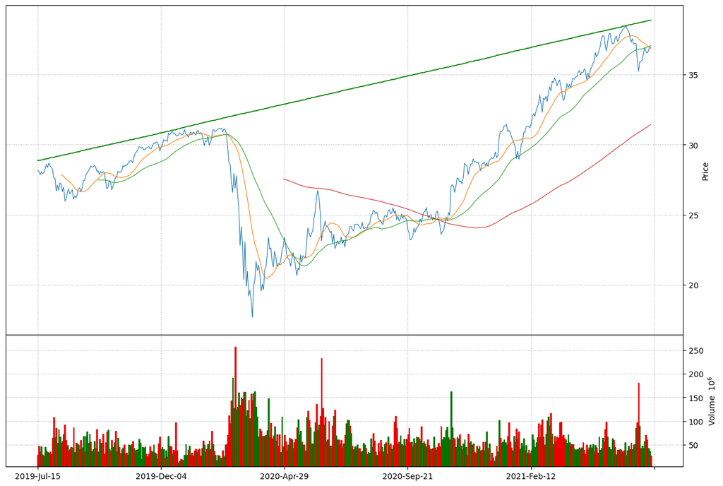

```python
edh.draw_graph("XLF", cache_dir, line_type="line", draw_mas=(20,50,200), draw_volume=True, time_delta=720, low_trend=False)
```

## Financials - 1 year trend with 20, 50 and 200 day SMA

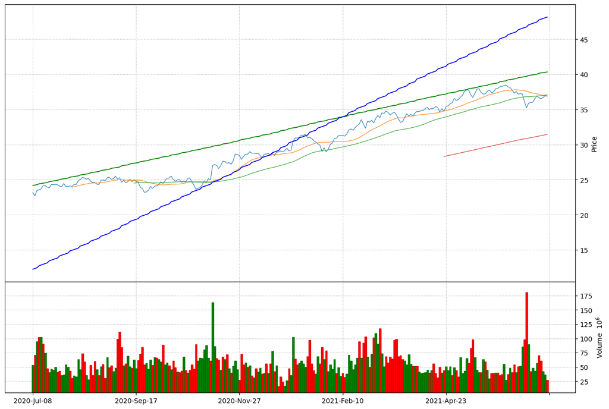

```python
edh.draw_graph("XLF", cache_dir, line_type="line", draw_mas=(20,50,200), draw_volume=True, time_delta=360, low_trend=True)
```

## Materials - 2 year trend with 20, 50 and 200 day SMA

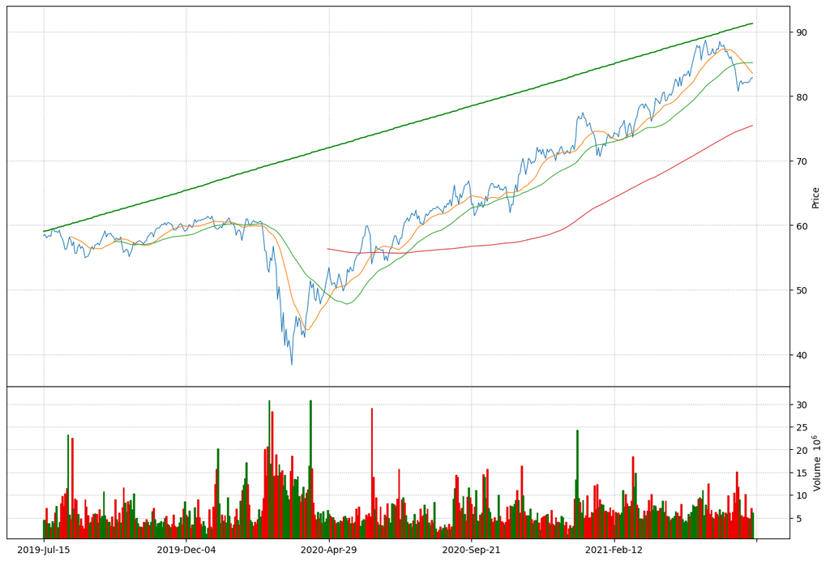

```python
edh.draw_graph("XLB", cache_dir, line_type="line", draw_mas=(20,50,200), draw_volume=True, time_delta=720, low_trend=False)
```

## Materials - 1 year trend with 20, 50 and 200 day SMA

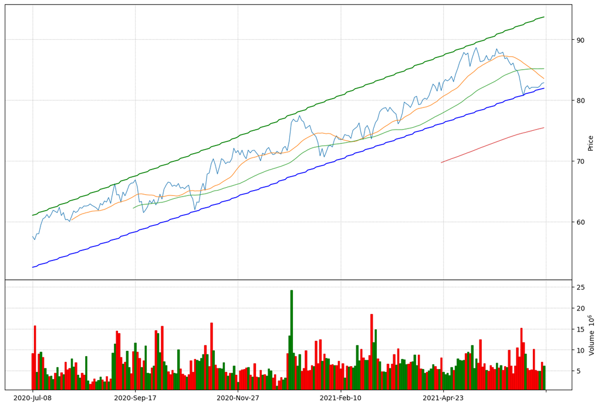

```python
edh.draw_graph("XLB", cache_dir, line_type="line", draw_mas=(20,50,200), draw_volume=True, time_delta=360, low_trend=True)
```